# ProjectReport

Deisy Diaz

6/2/2021

```r
setwd("C:/Users/jd100/Desktop/UCR Classes/Spring 21/Stat 167/Final Project")
video_game_data <- read_csv("Video_Games_Sales.csv")
```

In our data set, we have a total of 16 variables, listed below with what the variable stands for:

1. Name: Name of the game
2. Platform: Console on which the game is running
3. Year_of_Release: Year the game was released
4. Genre: The game’s category
5. Publisher: Game’s publisher
6. NA_Sales: Game Sales in North America (in millions of units)
7. EU_Sales: Game sales in the European Union
8. JP_Sales: Game sales in Japan
9. Other_Sales: Game sales in the rest of the world
10. Global_Sales: Total_Sales in the world
11. Critic_Score: Aggregate score compiled by Metacritic staff
12. Critic_Count: The number of critics used for Critic_Score
13. User_Score: Score by Metacritic’s subscribers
14. User_Count: Number of users who gave the user_score
15. Developer: Party responsible for creating the game
16. Rating: The ESRB rating

we have 8 character variables including: Name, Platform, Year_of_Release, Genre, Publisher, User_Score, Developer, and Rating. We also have 8 numeric variables NA_Sales, EU_Sales, JP_Sales, Other_Sales, Global_Sales, Critic_Score, Critic_Count, and User_Count. Although the variables Year_of_Release, and User_Score were character variables, we needed to convert them to doubles in order use them for our analysis. While all the variables were important, the variables we used to come to our conclusion on which games we recommend being discontinued, were Genre, Platform, Global_Sales and Critic_Score.

```r
video_game_data <-
  video_game_data %>%
  filter(!is.na(Name), !is.na(Platform), !is.na(Year_of_Release), !is.na(Genre), !is.na(Publisher), !is.na(NA_Sales), !is.na(EU_Sales), !is.na(JP_Sales), !is.na(Other_Sales), !is.na(Global_Sales), !is.na(Critic_Score), !is.na(User_Score), User_Score != "tbd", !is.na(Rating), !is.na(Developer))

video_game_data
```

```
## # A tibble: 6,947 x 16
##    Name  Platform Year_of_Release Genre Publisher NA_Sales EU_Sales JP_Sales
##    <chr> <chr>    <chr>           <chr> <chr>        <dbl>    <dbl>    <dbl>
##  1 Wii ~ Wii      2006            Spor~ Nintendo     41.4     29.0      3.77
##  2 Mari~ Wii      2008            Raci~ Nintendo     15.7     12.8      3.79
##  3 Wii ~ Wii      2009            Spor~ Nintendo     15.6     10.9      3.28
##  4 New ~ DS       2006            Plat~ Nintendo     11.3      9.14     6.5
##  5 Wii ~ Wii      2006            Misc  Nintendo     14.0      9.18     2.93
##  6 New ~ Wii      2009            Plat~ Nintendo     14.4      6.94     4.7
##  7 Mari~ DS       2005            Raci~ Nintendo      9.71     7.47     4.13
##  8 Wii ~ Wii      2007            Spor~ Nintendo      8.92     8.03     3.6
##  9 Kine~ X360     2010            Misc  Microsof~    15        4.89     0.24
## 10 Wii ~ Wii      2009            Spor~ Nintendo      9.01     8.49     2.53
## # ... with 6,937 more rows, and 8 more variables: Other_Sales <dbl>,
## #   Global_Sales <dbl>, Critic_Score <dbl>, Critic_Count <dbl>,
## #   User_Score <chr>, User_Count <dbl>, Developer <chr>, Rating <chr>
```

After removing any missing values, I did a count of the number of observations by genre to determine which of the genres had the most and least number of observations.

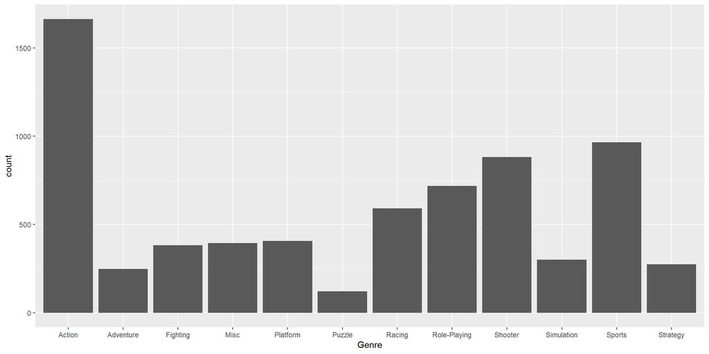

```r
ggplot(data = video_game_data) +
  stat_count(mapping = aes(x = Genre))
```

Then I analyzed the variance of the data in each numerical column. Although the User_Score variable presented as a character column, it was clearly a double numerical value. In order to analyze the variance of the variable, I converted all it’s values to doubles.

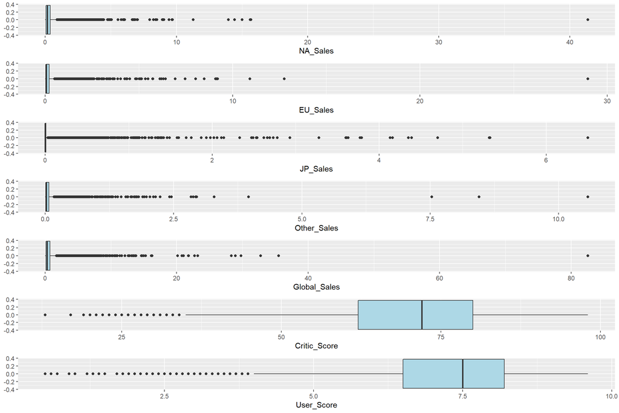

```r
video_game_data$User_Score <- as.double(video_game_data$User_Score)

gg <- ggplot(data = video_game_data)
var1 <- gg + geom_boxplot(mapping = aes(x = NA_Sales), fill = "light blue")
var2 <- gg + geom_boxplot(mapping = aes(x = EU_Sales), fill = "light blue")
var3 <- gg + geom_boxplot(mapping = aes(x = JP_Sales), fill = "light blue")
var4 <- gg + geom_boxplot(mapping = aes(x = Other_Sales), fill = "light blue")
var5 <- gg + geom_boxplot(mapping = aes(x = Global_Sales), fill = "light blue")
var6 <- gg + geom_boxplot(mapping = aes(x = Critic_Score), fill = "light blue")
var7 <- gg + geom_boxplot(mapping = aes(x = User_Score), fill = "light blue")

grid.arrange(var1, var2, var3, var4, var5, var6, var7, ncol = 1)
```